# Assignment 08

## Homework 8

#### Due Tuesday, November 16, 11:59 PM CT

Problems 1-3 are based on the random variable $X \sim \text{Binomial}(60, 0.4)$.

### Problem 1

### A

Calculate and report the mean and standard deviation of the distribution.

The mean is equal to $n \cdot p$ and the standard deviation is equal to $\sqrt{n \cdot p \cdot (1-p)}$

Therefore, the mean is 24 and the standard deviation is 3.79.

### B

Calculate and report $\mathsf{P}(X = 25)$

```r
dbinom(25, 60, 0.4)
```

```
## [1] 0.1004824
```

### C

Calculate and report $\mathsf{P}(X >= 25)$

```r
1 - pbinom(24, 60, 0.4)
```

```
## [1] 0.4442244
```

### D

Create a graph which displays the binomial distribution with bars for $x \ge 25$ colored in a different color from the rest to help visualize your answer to **C**.

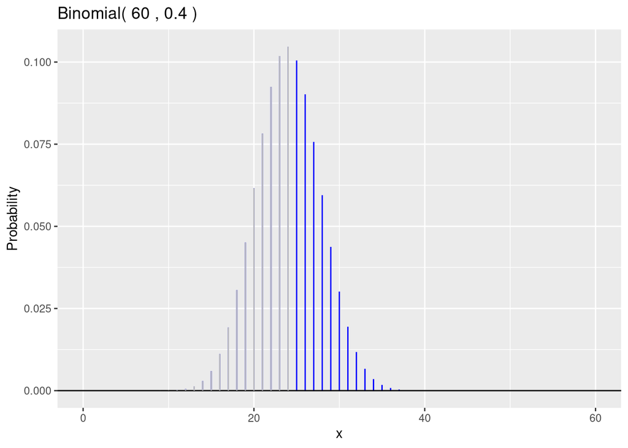

```r
gbinom(60, 0.4, a=0, b=60) +
  geom_binom_density(60, 0.4, a=0, b=24, color="grey")
```

### Problem 2

What is the probability that $X$ is within one, two, and three standard deviations of the mean? Round each probability to four decimal places.

```r
pbinom(27.79, 60, 0.4) - pbinom(20.21, 60, 0.4)
```

```
## [1] 0.643568
```

```r
pbinom(31.58, 60, 0.4) - pbinom(16.42, 60, 0.4)
```

```
## [1] 0.9528869
```

```r
pbinom(35.37, 60, 0.4) - pbinom(12.63, 60, 0.4)
```

```
## [1] 0.997814
```

### Problem 3

Draw a graph of this binomial distribution with vertical lines with different line types at the end points of the intervals 1, 2, and 3 sigma from the mean.

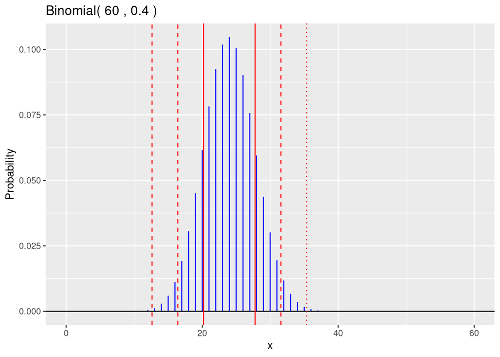

```r
gbinom(60, 0.4, a=0, b=60) +
  geom_vline(xintercept=27.79, color = "red", linetype="solid") +
  geom_vline(xintercept=20.21, color = "red", linetype="solid") +
  geom_vline(xintercept=31.58, color = "red", linetype="dashed") +
  geom_vline(xintercept=16.42, color = "red", linetype="dashed") +
  geom_vline(xintercept=35.37, color = "red", linetype="dotted") +
  geom_vline(xintercept=12.63, color = "red", linetype="dashed")
```

### Problem 4

### A

Create a tibble where each row corresponds to a binomial distribution with the following columns:

- `n` for $n = 1000,1001, \ldots, 10,000$
- `p` equal to 0.9 for each row
- `mu` equal to the mean
- `sigma` equal to the standard deviation
- `q.975` equal to the 0.975 quantile of the distribution
- `z = (q.975 - mu)/sigma`, the standardized z-score of the quantile
- `prob` equal to $\mathsf{P}(X \ge q.975)$, a right-tail probability for the distribution in each row

Display all columns and the rows of this table for which $n$ is a multiple of 1000.

```r
FINALQ4A <- tibble(
  n = 1000:10000,
  p = 0.9,
  mu = n * p,
  sigma = sqrt(mu * (1-p)),
  q.975 = qnorm(0.975),
  z = (q.975 - mu)/sigma,
  prob = qbinom(q.975, n, p)
)
FINALQ4A %>% filter(row_number() %% 1000 == 1) %>% print()
```

```
## # A tibble: 10 × 7
##        n     p    mu sigma q.975      z  prob
##    <int> <dbl> <dbl> <dbl> <dbl>  <dbl> <dbl>
##  1  1000   0.9   900  9.49  1.96  -94.7   NaN
##  2  2000   0.9  1800 13.4   1.96 -134.    NaN
##  3  3000   0.9  2700 16.4   1.96 -164.    NaN
##  4  4000   0.9  3600 19.0   1.96 -190.    NaN
##  5  5000   0.9  4500 21.2   1.96 -212.    NaN
##  6  6000   0.9  5400 23.2   1.96 -232.    NaN
##  7  7000   0.9  6300 25.1   1.96 -251.    NaN
##  8  8000   0.9  7200 26.8   1.96 -268.    NaN
##  9  9000   0.9  8100 28.5   1.96 -285.    NaN
## 10 10000   0.9  9000 30     1.96 -300.    NaN
```

### B

Use a line plot to show the relationship between $n$ on the x axis and $z$ on the y axis. Add a smooth curve to highlight the trend. Describe the pattern you see.

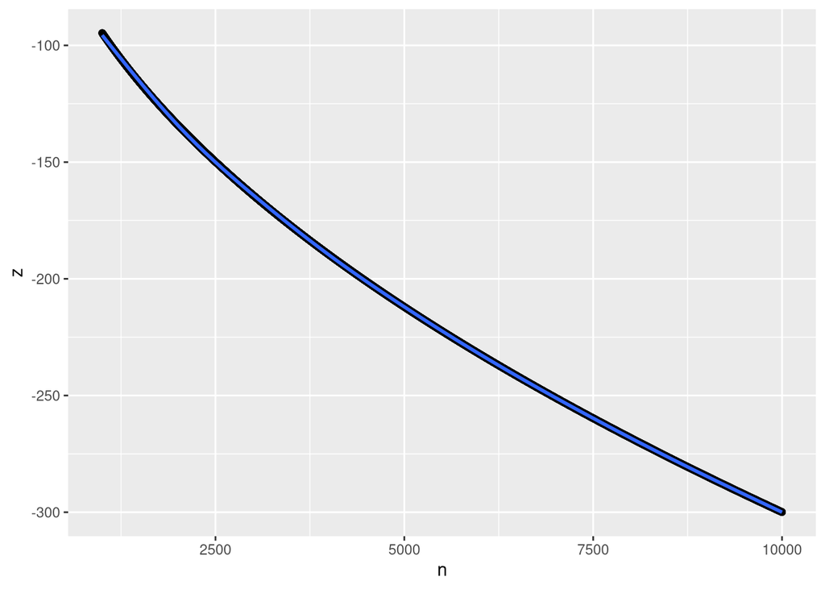

```r
ggplot(data = FINALQ4A) +
  geom_point(mapping = aes(x=n, y=z)) + geom_smooth(mapping = aes(x=n, y=z))
```

The z-score decreases logarithmic as the amount of trials increases.

### C

What is the average of the values of $z$ for $n > 9000$?

```r
FINALQ5C <- FINALQ4A %>% filter(n>9000)
mean(FINALQ5C$z)
```

```
## [1] -292.3107
```

### D

Plot the right tail probability `prob` on y axis versus `n` on the x axis.

### E

What is the average of the values of `prob` for $n > 9000$?

### Problem 5

### A

What is the 0.975 quantile of the standard normal distribution?

1.96

### B

What is the area to the right of this quantile?

### Problem 6

For the $\text{N}(500,100)$ distribution, find values $a$ and $b$ such that $a < b$, the area between $a$ and $b$ under the normal density is equal to 0.6, and $a$ and $b$ are equally distant from $\mu = 500$.

a = 415.84, b = 584.16

### Problem 7

Graph the $\text{N}(500,100)$ distribution and shade the area between $a$ and $b$ from the previous problem.

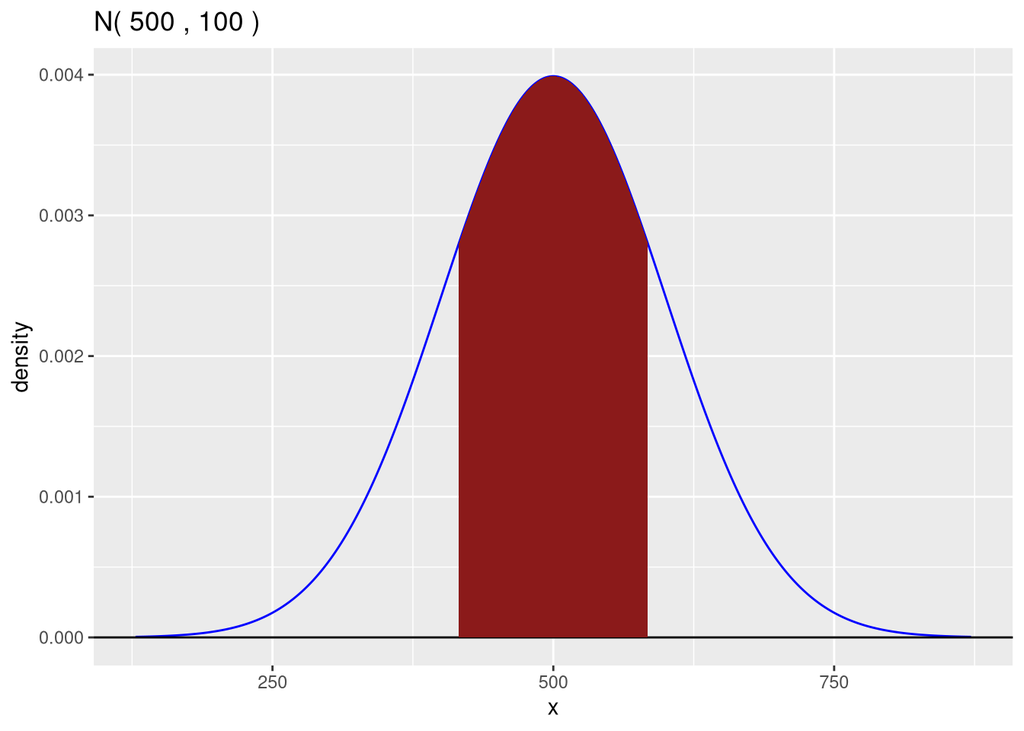

```r
gnorm(mu=500, sigma=100,) +
  geom_norm_fill(500, 100, a = 415.84, b = 584.16)
```